# Guía de trabajo Análisis de varianza y posteriores

Curso Introducción al Análisis de datos con R para la acuicultura

Dr. José A. Gallardo y Dra. María Angélica Rueda.

Pontificia Universidad Católica de Valparaíso  
jose.gallardo@pucv.cl

11 July 2021

#### **Introducción**

**Análisis de Varianza**

**Comparación a posteriori**

#### **Objetivos de aprendizaje**

Los objetivos de aprendizaje de esta guía son:

**1**. - Elaborar hipótesis estadísticas.

**2**. - Realizar análisis de varianza y comparaciones posteriores.

**3**. - Elaborar un reporte dinámico en formato pdf con **[Rmarkdown](https://rmarkdown.rstudio.com/)**.

#### **Comandos**

A continuación, se presentan algunos comandos que deberá usar para resolver los ejercicios de esta guía.

**1.-** :**lm()**

**2.-** :**aov()**

### **Ejercicio 1.** **Elaborar archivo Rmarkdown**

Usando lo aprendido en la unidad 1 del diplomado elabore y configure un archivo o file con extensión **.Rmd** y configurelo para exportar el resultado como un documento dinámico **pdf**.

Utilice el siguiente ejemplo para completar la información de metadatos: Título: Reporte inferencia estadística, nombre del autor: Su nombre.

Luego guarde inmediatamente su *script* como **script_9_nombre_apellido.Rmd**. Al finalizar la actividad deberá exportar y almacenar este script en su carpeta drive de tareas.

### **Ejercicio 2.** **Configuración del reporte**

En el primer bloque de códigos o **chunk** configure los comandos de la siguiente manera *knitr::opts_chunk$set(echo = TRUE)* y cargue las librerías **stats**, **graphics**, **ggplot2**, **readxl**, **pander**, **dplyr** y **knitr**.

```r
knitr::opts_chunk$set(echo = TRUE)

# Librería stats está instalada por defecto en la base de R
library(stats)

# Librería graphics está instalada por defecto en la base de R
library(graphics)

# Librería para gráficas avanzadas
library(ggplot2)

# Librería para importar datos
library(readxl)

# Librería para mostrar en formato tabla los resultados de un objeto
library(pander)

# Librería para usar funciones de tidyverse
library(dplyr)

# Librería para hacer tablas
library(knitr)
```

Ejecute cada uno de los siguientes ejercicios en uno o más bloques de códigos diferentes. Sea ordenado y documente su reporte adecuadamente.

RESUMEN Ejercicio 3 ANOVA 1 VIA 1 variable respuesta y un factor con 2 niveles.

Simular ANOVA 1 via con transformación arcoseno de Survival (%). https://scielo.conicyt.cl/scielo.php?pid=S0718-560X2019000300440&script=sci_arttext

Ejercicio 4 ANOVA 1 VIA 1 variable respuesta y un factor con 3 niveles. + comparaciones a posteriori

Simular One-way analysis of variance (ANOVA) was used to determine the effects of ozonation on growth and hematological parameters https://fas.biomedcentral.com/articles/10.1186/s41240-017-0079-3

Ejercicio 5 ANOVA 2 VIAS 1 variable respuesta y dos factores con interacción.

Simular datos Fig. 2. Susceptibility (mortality) of Chinook salmon to Vibrio anguillarum. Anova con interacción desde paper https://doi.org/10.1016/j.aquaculture.2013.12.010

Los datos **Tilapia_data.xlsx** se refieren a la longitud (**Longitud_cm**) y el peso (**Peso_g**) de 100 tilapias machos de cultivos provenientes del Ecuador.

**a).** Importe el set de datos **Tilapia_data.xlsx** usando la función **read_excel()** de la librería **readxl**, llame al objeto Tilapia. Explore el set de datos usando las funciones **head()**, **str()** y **summary()**.

```r
Tilapia <- read_excel("Tilapia_data.xlsx")
head(Tilapia)
```

```
## # A tibble: 6 x 3
##      ID Longitud_cm Peso_g
##   <dbl>       <dbl>  <dbl>
## 1     1        14.8     55
## 2     2        15.3     65
## 3     3        15.7     66
## 4     4        16.3     70
## 5     5        16.4     71
## 6     6        16.6     72
```

```r
str(Tilapia)
```

```
## tibble [100 × 3] (S3: tbl_df/tbl/data.frame)
##  $ ID         : num [1:100] 1 2 3 4 5 6 7 8 9 10 ...
##  $ Longitud_cm: num [1:100] 14.8 15.3 15.7 16.3 16.4 ...
##  $ Peso_g     : num [1:100] 55 65 66 70 71 72 73 74 76 79 ...
```

```r
summary(Tilapia)
```

```
##        ID          Longitud_cm        Peso_g
##  Min.   :  1.00   Min.   :14.79   Min.   : 55.0
##  1st Qu.: 25.75   1st Qu.:18.48   1st Qu.:104.0
##  Median : 50.50   Median :19.77   Median :122.0
##  Mean   : 50.50   Mean   :19.76   Mean   :127.1
##  3rd Qu.: 75.25   3rd Qu.:21.01   3rd Qu.:147.2
##  Max.   :100.00   Max.   :24.67   Max.   :217.0
```

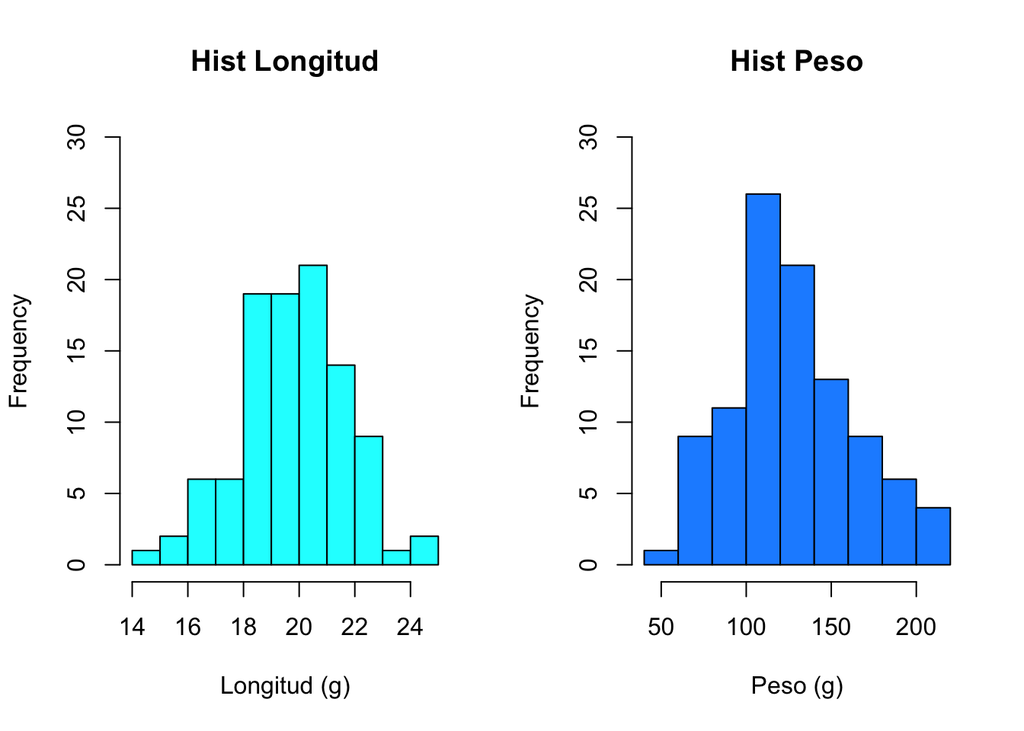

```r
# Promedio y varianza de la variable Longitud
Promedio_Longitud <- mean(Tilapia$Longitud_cm)
Var_Longitud <- var(Tilapia$Longitud_cm)

# Promedio y varianza de la variable Peso
Promedio_Peso <- mean(Tilapia$Peso_g)
Var_Peso <- var(Tilapia$Peso_g)

# Histogramas de las variables Longitud y Peso
par(mfrow = c(1,2))
hist(Tilapia$Longitud_cm, main= "Hist Longitud", xlab= "Longitud (g)", ylim= c(0,30),col="cyan")
hist(Tilapia$Peso_g, main= "Hist Peso", xlab= "Peso (g)", ylim= c(0,30),col="dodgerblue")
```

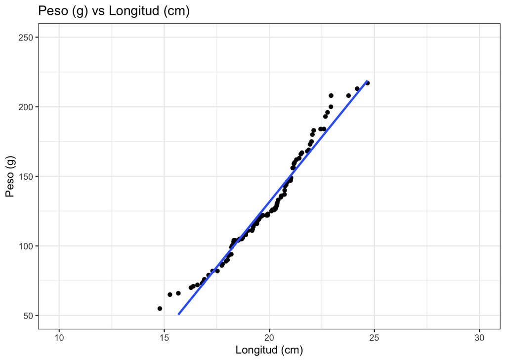

```r
# Gráfico de dispersión entre x e y
ggplot(Tilapia, aes(x=Tilapia$Longitud_cm, y=Tilapia$Peso_g))+
  geom_point()+
  ggtitle("Peso (g) vs Longitud (cm)") + geom_smooth(method=lm, se=FALSE)+
  scale_x_continuous(name = "Longitud (cm)", limits = c(10, 30), breaks = seq(10, 30, 5))+
  scale_y_continuous(name = "Peso (g)", limits = c(50,250), breaks = seq(50, 250, 50))+
  theme(plot.title = element_text(hjust = 0.5), panel.background = element_blank(), axis.line = element_line(color="black"), axis.line.x = element_line(color="black"))+
  theme_bw()
```

**c).** Escriba su hipótesis nula y alternativa para este experimento.

```r
# **H~0~**: $\rho$ = 0

# **H~1~**: $\rho$ $\ne$ 0
```

**d).** Realice una prueba de hipótesis para la correlación entre X e Y usando la función **cor.test()**, (llame al objecto cor_L_P) y obtenga los intervalos de confianza usando **cor.test()$conf.int** (llame a este objeto IC_cor_L_P) . Considere en **cor.test()** como nivel de confianza para la prueba el 95% y el método de Pearson. Para mostrar los resultados de la prueba de correlación usar la función **pander()** sobre el objeto **cor_L_P**, en el parámetro *caption* de la función **pander()** colocar “Prueba de hipótesis para el coeficiente de correlación entre Longitud y Peso.”.

```r
cor_L_P<- cor.test(x=Tilapia$Longitud_cm , y=Tilapia$Peso_g , method = "pearson", conf.level = 0.95)
cor_L_P
```

```
##
##  Pearson's product-moment correlation
##
## data:  Tilapia$Longitud_cm and Tilapia$Peso_g
## t = 52.581, df = 98, p-value < 2.2e-16
## alternative hypothesis: true correlation is not equal to 0
## 95 percent confidence interval:
##  0.9744019 0.9883704
## sample estimates:
##       cor
## 0.9827343
```

```r
IC_cor_L_P <-cor_L_P$conf.int
IC_cor_L_P
```

```
## [1] 0.9744019 0.9883704
## attr(,"conf.level")
## [1] 0.95
```

```r
pander::pander(cor_L_P, caption = "Prueba de hipótesis para el coeficiente de correlación entre Longitud y Peso.")
```

Prueba de hipótesis para el coeficiente de correlación entre Longitud y Peso.

| Test statistic | df | P value | Alternative hypothesis | cor |
| --- | --- | --- | --- | --- |
| 52.58 | 98 | 1.261e-73 * * * | two.sided | 0.9827 |

**e).** Interprete los resultados.

```r
# De los resultados obtenidos de la prueba, se observa que el p-valor= 1.261e-73 es menor al nivel de significación del 5%; concluyendo que hay evidencia estadísticamente significativa para rechazar H0. Por lo tanto, la correlación entre la longitud y el peso es distinta de cero.
```

ANOVA 2 VIAS 1 variable respuesta y 2 factores con 2 niveles.